# Disease-group comparison with spatialCooccur

This vignette walks through the disease- / condition-group comparison workflow in **spatialCooccur**. The pattern is:

1. Collect per-sample spatial transcriptomics data (one image per sample, or multiple images grouped by patient).
2. Compute a spatial co-occurrence score *per sample* with one of the `*_per_sample()` helpers.
3. Test for differences between groups (e.g. disease vs. control) with `compare_groups()`.
4. Visualize with `plot_group_delta_heatmap()`, `plot_pair_boxplot()`, or `plot_volcano_groups()`.

```r
library(spatialCooccur)
```

# Simulate a two-group dataset

## How `generate_sim()` builds one sample

Before generating the full disease/control dataset, it helps to look at what a single sample produced by `generate_sim()` actually contains.

A sample is a flat `data.frame` of cells with `x`, `y`, and `cell_type` columns. With `test_type = "distribute"`:

1. All cells are first dropped uniformly at random in a `max_loc x max_loc` box.
2. Each cell is assigned one of `n_types` cell types.
3. A fraction `close_ratio` of the `cell_type_2` cells is then *moved* next to a randomly chosen `cell_type_1` cell, at distance `distance_param` (with small Gaussian jitter).

So `close_ratio` controls the strength of the planted 1 ↔︎ 2 spatial interaction. `distance_param` controls how *close* the pairing is.

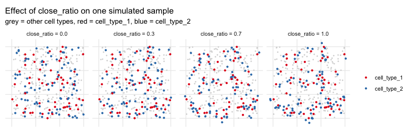

```r
library(ggplot2)
# A small parameter sweep on close_ratio, all other params fixed.
ratios  <- c(0.0, 0.3, 0.7, 1.0)
df_list <- lapply(ratios, function(r) {
  d <- generate_sim(close_ratio    = r,
                    n_types        = 5,
                    n_cells        = 400,
                    max_loc        = 300,
                    test_type      = "distribute",
                    distance_param = 15,
                    seed           = 7)
  d$close_ratio <- sprintf("close_ratio = %.1f", r)
  d$.target     <- ifelse(as.character(d$cell_type) %in%
                            c("cell_type_1", "cell_type_2"),
                          as.character(d$cell_type), "other")
  d
})
df_sweep <- do.call(rbind, df_list)
df_sweep$close_ratio <- factor(df_sweep$close_ratio,
                               levels = sprintf("close_ratio = %.1f", ratios))

ggplot(df_sweep, aes(x = x, y = y)) +
  geom_point(data = subset(df_sweep, .target == "other"),
             color = "grey85", size = 0.35) +
  geom_point(data = subset(df_sweep, .target != "other"),
             aes(color = .target), size = 0.9) +
  facet_wrap(~ close_ratio, nrow = 1) +
  coord_equal() +
  scale_color_manual(values = c(cell_type_1 = "#E41A1C", cell_type_2 = "#377EB8")) +
  labs(title = "Effect of close_ratio on one simulated sample",
       subtitle = "grey = other cell types, red = cell_type_1, blue = cell_type_2",
       x = NULL, y = NULL, color = NULL) +
  theme_minimal() +
  theme(axis.text = element_blank(),
        axis.ticks = element_blank(),
        panel.grid.minor = element_blank())
```

As `close_ratio` grows from 0 to 1 you can see the red and blue points visibly clump into pairs while the grey background stays uniform. That clumping is exactly the signal `nhood_enrichment` should pick up.

To make `distance_param` concrete, zoom into one sample and draw a segment from each red seed to its paired blue partner:

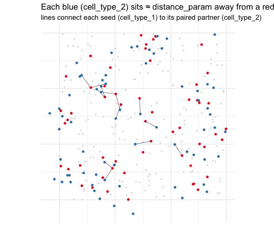

```r
one <- generate_sim(close_ratio    = 1.0,
                    n_types        = 5,
                    n_cells        = 300,
                    max_loc        = 300,
                    test_type      = "distribute",
                    distance_param = 25,
                    seed           = 42)

# Reconstruct the seed-partner pairs deterministically by re-running the
# seeding logic of generate_sim() so we can draw the connecting segments.
set.seed(42)
.x  <- runif(300, 0, 300); .y <- runif(300, 0, 300)
.ct <- sample(paste0("cell_type_", 1:5), 300, replace = TRUE)
i1  <- which(.ct == "cell_type_1")
i2  <- which(.ct == "cell_type_2")
n_pairs <- round(length(i2) * 1.0)
ic1 <- sample(i1, n_pairs, replace = TRUE)
ic2 <- sample(i2, n_pairs)

# Use the moved coordinates of cell_type_2 from the simulated sample,
# matched back by index.
segs <- data.frame(
  x = one$x[ic1], y = one$y[ic1],
  xend = one$x[ic2], yend = one$y[ic2]
)
# Keep only nearby pairs for clarity in the zoom
zoom <- segs[segs$x > 50 & segs$x < 230 & segs$y > 50 & segs$y < 230, ]

ggplot() +
  geom_point(data = one, aes(x = x, y = y),
             color = "grey85", size = 0.4) +
  geom_segment(data = zoom,
               aes(x = x, y = y, xend = xend, yend = yend),
               color = "grey40", linewidth = 0.3) +
  geom_point(data = subset(one, cell_type == "cell_type_1"),
             aes(x = x, y = y), color = "#E41A1C", size = 1.2) +
  geom_point(data = subset(one, cell_type == "cell_type_2"),
             aes(x = x, y = y), color = "#377EB8", size = 1.2) +
  coord_equal() +
  labs(title = "Each blue (cell_type_2) sits ≈ distance_param away from a red seed",
       subtitle = "lines connect each seed (cell_type_1) to its paired partner (cell_type_2)",
       x = NULL, y = NULL) +
  theme_minimal() +
  theme(axis.text = element_blank(), axis.ticks = element_blank())
```

`generate_sim_groups()` then calls `generate_sim()` once per sample, using a group-specific `close_ratio` (plus a small per-sample noise), so the result is `n_samples_per_group x length(group_close_ratio)` samples sharing the same coordinate space but differing in how strongly the 1 ↔︎ 2 interaction is planted.

```r
set.seed(1)
df_groups <- generate_sim_groups(
  n_samples_per_group = 8,
  group_close_ratio = list(disease = 0.95, control = 0.05),
  n_types = 5,
  n_cells = 500,
  test_type = "distribute",
  distance_param = 10,
  between_sample_noise = 0.02,
  seed = 1
)
head(df_groups)
```

```
#>                         x        y   cell_type sample_id   group   patient
#> disease_1_cell1 239.64211 545.8865 cell_type_1 disease_1 disease disease_1
#> disease_1_cell2  78.11157 414.1219 cell_type_4 disease_1 disease disease_1
#> disease_1_cell3 239.06971 622.5321 cell_type_2 disease_1 disease disease_1
#> disease_1_cell4 705.19295  94.6877 cell_type_1 disease_1 disease disease_1
#> disease_1_cell5 300.35948 331.8670 cell_type_1 disease_1 disease disease_1
#> disease_1_cell6 584.28894 446.3800 cell_type_4 disease_1 disease disease_1
```

```r
table(df_groups$sample_id, df_groups$group)
```

```
#>
#>             control disease
#>   control_1     500       0
#>   control_2     500       0
#>   control_3     500       0
#>   control_4     500       0
#>   control_5     500       0
#>   control_6     500       0
#>   control_7     500       0
#>   control_8     500       0
#>   disease_1       0     500
#>   disease_2       0     500
#>   disease_3       0     500
#>   disease_4       0     500
#>   disease_5       0     500
#>   disease_6       0     500
#>   disease_7       0     500
#>   disease_8       0     500
```

The settings above are tuned so the planted `cell_type_1` ↔︎ `cell_type_2` signal is strong enough that downstream `compare_groups()` reaches BH-adjusted significance across the full 5 × 5 cluster grid. With smaller `n_samples_per_group` or a narrower `close_ratio` gap, the Wilcoxon p-value floor combined with 25-pair multiple-testing correction often prevents `padj < 0.05` even when the planted effect is real — keep that in mind when designing your own experiments.

`df_groups` is a long-format data.frame with columns `x`, `y`, `cell_type`, `sample_id`, `group`, `patient`. The same shape is what the `*_per_sample()` helpers accept directly; for Seurat input they read the equivalent fields from `meta.data` and `@images`.

## Spatial map of the simulated samples

[figure not shown]

```r
library(ggplot2)

# Order panels so disease and control sit on contiguous rows
df_groups$sample_id <- factor(
  df_groups$sample_id,
  levels = unique(df_groups$sample_id[order(df_groups$group, df_groups$sample_id)])
)

ggplot(df_groups, aes(x = x, y = y, color = cell_type)) +
  geom_point(size = 0.6, alpha = 0.8) +
  facet_wrap(~ group + sample_id, nrow = 4) +
  coord_equal() +
  scale_color_manual(values = manual_colors[seq_len(nlevels(df_groups$cell_type))]) +
  guides(color = guide_legend(override.aes = list(size = 2.5))) +
  labs(title = "Simulated samples by disease group",
       x = NULL, y = NULL, color = "cell type") +
  theme_minimal() +
  theme(axis.text = element_blank(),
        axis.ticks = element_blank(),
        panel.grid.minor = element_blank())
```

To highlight the planted interaction, restrict to the two seeded cell types and overlay them on a grey background of all other cells:

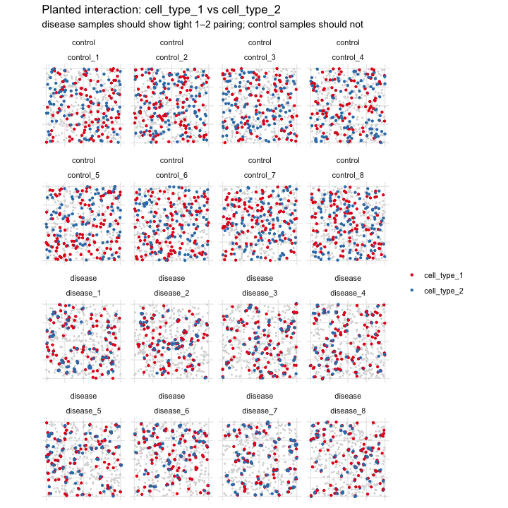

```r
target <- c("cell_type_1", "cell_type_2")
df_groups$.target <- ifelse(as.character(df_groups$cell_type) %in% target,
                            as.character(df_groups$cell_type), "other")

ggplot(df_groups, aes(x = x, y = y)) +
  geom_point(data = subset(df_groups, .target == "other"),
             color = "grey85", size = 0.4) +
  geom_point(data = subset(df_groups, .target != "other"),
             aes(color = .target), size = 0.9) +
  facet_wrap(~ group + sample_id, nrow = 4) +
  coord_equal() +
  scale_color_manual(values = c(cell_type_1 = "#E41A1C", cell_type_2 = "#377EB8")) +
  labs(title = "Planted interaction: cell_type_1 vs cell_type_2",
       subtitle = "disease samples should show tight 1–2 pairing; control samples should not",
       x = NULL, y = NULL, color = NULL) +
  theme_minimal() +
  theme(axis.text = element_blank(),
        axis.ticks = element_blank(),
        panel.grid.minor = element_blank())
```

```r
df_groups$.target <- NULL
```

# Per-sample neighborhood enrichment

```r
per_sample <- nhood_enrichment_per_sample(
  df_groups,
  sample_key   = "sample_id",
  group_key    = "group",
  cluster_key  = "cell_type",
  patient_key  = "patient",
  neighbors.k  = 12,
  n_perms      = 200,
  n_jobs       = 1,
  seed         = 1
)
head(per_sample)
```

```
#>   sample_id   cluster_i   cluster_j     zscore    count   group   patient
#> 1 control_1 cell_type_1 cell_type_1  4.0547626 26.59633 control control_1
#> 2 control_1 cell_type_2 cell_type_1 -0.5807198 16.84643 control control_1
#> 3 control_1 cell_type_3 cell_type_1 -0.8365583 18.54675 control control_1
#> 4 control_1 cell_type_4 cell_type_1 -1.1248416 17.31725 control control_1
#> 5 control_1 cell_type_5 cell_type_1 -0.7344125 19.41918 control control_1
#> 6 control_1 cell_type_1 cell_type_2 -2.2008546 16.47835 control control_1
```

Each row is `sample_id x cluster_i x cluster_j`. The factor levels of `cell_type` are harmonized across samples so that the `cluster_i`, `cluster_j` columns are directly comparable.

## Sanity check: per-group enrichment heatmaps

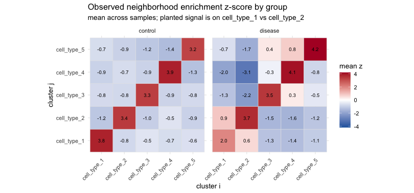

```r
library(ggplot2)

# Average the per-sample z-score within group (this is the input compare_groups
# will then test against zero between groups).
mean_z <- aggregate(zscore ~ cluster_i + cluster_j + group,
                    data = per_sample, FUN = function(x) mean(x, na.rm = TRUE))

# Symmetric color limits around 0 so disease vs control are directly comparable
lim <- max(abs(mean_z$zscore), na.rm = TRUE)

ggplot(mean_z, aes(x = cluster_i, y = cluster_j, fill = zscore)) +
  geom_tile(color = "grey90", linewidth = 0.2) +
  geom_text(aes(label = sprintf("%.1f", zscore)), size = 2.7) +
  facet_wrap(~ group) +
  scale_fill_gradient2(low = "#2166AC", mid = "white", high = "#B2182B",
                       midpoint = 0, limits = c(-lim, lim)) +
  coord_equal() +
  labs(title = "Observed neighborhood enrichment z-score by group",
       subtitle = "mean across samples; planted signal is on cell_type_1 vs cell_type_2",
       x = "cluster i", y = "cluster j", fill = "mean z") +
  theme_minimal() +
  theme(axis.text.x = element_text(angle = 45, hjust = 1))
```

You can also look at this group-mean object as a small table for a direct numeric comparison:

```r
target_pair <- subset(mean_z,
                      cluster_i == "cell_type_1" & cluster_j == "cell_type_2")
target_pair
```

```
#>      cluster_i   cluster_j   group     zscore
#> 6  cell_type_1 cell_type_2 control -1.1695215
#> 31 cell_type_1 cell_type_2 disease  0.8866004
```

For the radius-based ratio, the local interaction score, and the interaction-spot count, use the parallel helpers:

```r
cooccur_ratio_per_sample(
  df_groups, sample_key = "sample_id", group_key = "group",
  cluster_key = "cell_type", patient_key = "patient",
  radius = 30, k = 15
)

cooccur_local_per_sample(
  df_groups, sample_key = "sample_id", group_key = "group",
  cluster_key = "cell_type",
  cluster_x = "cell_type_1", cluster_y = "cell_type_2",
  patient_key = "patient",
  neighbors.k = 15, radius = 30
)
```

# Group comparison

`compare_groups()` runs a per-cluster-pair test between two groups. Set `ref_group` to make the sign of `effect` interpretable (`effect = mean(test) - mean(reference)`).

## Algorithm

Let $S$ be the set of samples, $G_s \in \{g_\mathrm{ref}, g_\mathrm{test}\}$ the group of sample $s$, and $V_{s,i,j}$ the per-sample score (e.g. the z-score from `nhood_enrichment_per_sample()`) for the ordered cluster pair $(i, j)$. `compare_groups()` iterates over every unique $(i, j)$ and runs the chosen two-group test on the vector $\{V_{s,i,j}\}_{s \in S}$ split by $G_s$.

For each pair it reports

$$\hat{\mu}_g \;=\; \frac{1}{|S_g|}\sum_{s \in S_g} V_{s,i,j},
\qquad
\widehat{\text{effect}}_{i,j} \;=\; \hat{\mu}_{g_\mathrm{test}} -
\hat{\mu}_{g_\mathrm{ref}},$$

where $S_g = \{s : G_s = g\}$.

After all pairs are tested, raw $p$-values $p_{i,j}$ are corrected for multiple testing across pairs:

$$\tilde{p}_{i,j} \;=\; \mathrm{adjust}\bigl(\{p_{i,j}\};\,
\text{method}\bigr),$$

defaulting to the Benjamini–Hochberg FDR procedure ($\tilde{p}_{(k)} = \min_{m \ge k}\bigl\{\frac{M}{m} p_{(m)}\bigr\}$, with $M$ the number of pairs and $p_{(k)}$ the $k$-th smallest $p$-value).

The four `method` choices differ only in how each per-pair $p_{i,j}$ is computed.

### `method = "wilcox"` — Wilcoxon rank-sum

Let $V^{(\mathrm{ref})}$ and $V^{(\mathrm{test})}$ denote the per-sample scores in each group (sizes $n_1, n_2$), and let $R_k$ be the rank of $V^{(\mathrm{test})}_k$ when all $n_1 + n_2$ values are pooled and ranked. The Mann–Whitney $U$ statistic is

$$U \;=\; \sum_{k=1}^{n_2} R_k \;-\; \frac{n_2(n_2+1)}{2}.$$

Under the null ($V^{(\mathrm{ref})}$ and $V^{(\mathrm{test})}$ share a distribution),

$$\mathbb{E}[U] = \frac{n_1 n_2}{2}, \quad
\mathrm{Var}(U) = \frac{n_1 n_2 (n_1 + n_2 + 1)}{12},$$

and the two-sided $p$-value comes from the normal approximation in `stats::wilcox.test(..., exact = FALSE)`.

This test is non-parametric and robust, which makes it the safest default when you have a handful of samples per group.

### `method = "t"` — Welch’s two-sample $t$

Same per-pair split as above. Let $\bar V_g$, $s_g^2$ be the sample mean and unbiased variance in each group. Welch’s statistic is

$$t \;=\; \frac{\bar V^{(\mathrm{test})} - \bar V^{(\mathrm{ref})}}
{\sqrt{\dfrac{s_1^2}{n_1} + \dfrac{s_2^2}{n_2}}}$$

with Welch–Satterthwaite degrees of freedom

$$\nu \;=\; \frac{\left(\dfrac{s_1^2}{n_1} + \dfrac{s_2^2}{n_2}\right)^2}
{\dfrac{(s_1^2/n_1)^2}{n_1 - 1} +
\dfrac{(s_2^2/n_2)^2}{n_2 - 1}}.$$

Use this if you trust approximate normality of the per-sample scores.

### `method = "lmm"` — linear mixed model

When you have multiple images per patient, you should not treat them as independent observations. For a given pair $(i, j)$, write the score of image $k$ from patient $p$ as

$$V_{p,k,i,j} \;=\; \beta_0 \;+\; \beta_1 \, \mathbb{1}\{G_{p,k} =
g_\mathrm{test}\}
\;+\; u_p \;+\; \varepsilon_{p,k},$$

with random patient intercept $u_p \sim \mathcal{N}(0, \sigma_u^2)$ and residuals $\varepsilon_{p,k} \sim \mathcal{N}(0, \sigma_\varepsilon^2)$.

`compare_groups()` fits this with `lme4::lmer(value ~ group + (1 | patient))`, then tests $H_0\!: \beta_1 = 0$ with a Wald-z approximation using the $t$-value from `summary(fit)$coefficients`:

$$z \;=\; \frac{\hat\beta_1}{\widehat{\mathrm{SE}}(\hat\beta_1)},
\qquad
p \;=\; 2\,\Phi(-|z|).$$

If each patient contributes only a single observation the LMM collapses to OLS and `compare_groups()` falls back to `lm()`. The Wald-z $p$-value is approximate; for stricter inference fit with `lmerTest` outside the package.

### `method = "perm"` — group-label permutation

Let $\Delta = \hat\mu_{g_\mathrm{test}} - \hat\mu_{g_\mathrm{ref}}$ be the observed mean difference for pair $(i, j)$. We then shuffle the group labels $B$ times (`n_perms`) to build a null distribution.

Without `patient_key`, every permutation reassigns sample-level labels independently:

$$\Delta^{(b)} \;=\; \hat\mu^{(b)}_{g_\mathrm{test}} -
\hat\mu^{(b)}_{g_\mathrm{ref}},
\quad b = 1, \dots, B.$$

With `patient_key`, labels are shuffled at the patient level (each patient keeps the same label across all of its images), which preserves within-patient correlation.

The two-sided $p$-value uses the standard $+1$-smoothed estimator

$$p \;=\; \frac{1 \;+\; \#\{b : |\Delta^{(b)}| \ge |\Delta|\}}{1 \;+\; B},$$

avoiding $p = 0$ in finite-$B$ samples. This is the preferred method when the per-sample score distribution is far from normal or when you need patient-level blocking.

### Multiple-testing adjustment

All $p$-values are passed through `stats::p.adjust(..., method = adjust)`. The default `"BH"` controls the false discovery rate across the $M$ tested cluster pairs at the chosen level $\alpha$ by

$$k^{*} \;=\; \max\Bigl\{k : p_{(k)} \le \frac{k}{M}\,\alpha\Bigr\},$$

and rejecting all pairs with $p_{(k)} \le p_{(k^*)}$. The returned `padj` column holds the BH-adjusted values directly, so a downstream $\tilde p_{i,j} < \alpha$ check gives exactly the BH decision.

```r
cmp_wilcox <- compare_groups(
  per_sample,
  value     = "zscore",
  method    = "wilcox",
  adjust    = "BH",
  ref_group = "control"
)
head(cmp_wilcox)
```

```
#>     cluster_i   cluster_j n_total n_control n_disease mean_control mean_disease
#> 1 cell_type_2 cell_type_4      16         8         8   -0.7143723   -3.0595068
#> 2 cell_type_4 cell_type_5      16         8         8   -1.4024150    0.7845261
#> 3 cell_type_1 cell_type_2      16         8         8   -1.1695215    0.8866004
#> 4 cell_type_3 cell_type_5      16         8         8   -1.1665573    0.3542269
#> 5 cell_type_4 cell_type_3      16         8         8   -0.8925690    0.3170598
#> 6 cell_type_2 cell_type_3      16         8         8   -0.7882491   -2.1696096
#>      effect statistic            p       padj
#> 1 -2.345134        64 0.0009391057 0.02347764
#> 2  2.186941         2 0.0019475276 0.02422526
#> 3  2.056122         4 0.0038760414 0.02422526
#> 4  1.520784         4 0.0038760414 0.02422526
#> 5  1.209629         9 0.0181290079 0.09064504
#> 6 -1.381360        54 0.0239486749 0.09978615
```

When you have multiple images per patient, prefer a mixed model (random intercept on patient) or a patient-blocked permutation:

```r
cmp_lmm <- compare_groups(
  per_sample,
  value       = "zscore",
  method      = "lmm",
  patient_key = "patient",
  ref_group   = "control"
)
head(cmp_lmm)
```

```
#>     cluster_i   cluster_j n_total n_control n_disease mean_control mean_disease
#> 1 cell_type_4 cell_type_5      16         8         8   -1.4024150    0.7845261
#> 2 cell_type_2 cell_type_4      16         8         8   -0.7143723   -3.0595068
#> 3 cell_type_3 cell_type_5      16         8         8   -1.1665573    0.3542269
#> 4 cell_type_1 cell_type_2      16         8         8   -1.1695215    0.8866004
#> 5 cell_type_2 cell_type_3      16         8         8   -0.7882491   -2.1696096
#> 6 cell_type_2 cell_type_1      16         8         8   -0.7847584    0.5818636
#>      effect statistic            p         padj
#> 1  2.186941  5.760703 4.930889e-05 0.0008784283
#> 2 -2.345134 -5.560111 7.027426e-05 0.0008784283
#> 3  1.520784  4.383961 6.237827e-04 0.0051981893
#> 4  2.056122  4.100430 1.081224e-03 0.0067576493
#> 5 -1.381360 -2.723571 1.647772e-02 0.0668813541
#> 6  1.366622  2.714367 1.677772e-02 0.0668813541
```

```r
cmp_perm <- compare_groups(
  per_sample,
  value       = "zscore",
  method      = "perm",
  patient_key = "patient",
  n_perms     = 500,
  ref_group   = "control",
  seed        = 1
)
head(cmp_perm)
```

```
#>     cluster_i   cluster_j n_total n_control n_disease mean_control mean_disease
#> 1 cell_type_1 cell_type_2      16         8         8   -1.1695215    0.8866004
#> 2 cell_type_2 cell_type_4      16         8         8   -0.7143723   -3.0595068
#> 3 cell_type_3 cell_type_5      16         8         8   -1.1665573    0.3542269
#> 4 cell_type_4 cell_type_5      16         8         8   -1.4024150    0.7845261
#> 5 cell_type_2 cell_type_3      16         8         8   -0.7882491   -2.1696096
#> 6 cell_type_1 cell_type_1      16         8         8    3.8440964    1.9809071
#>      effect statistic           p       padj
#> 1  2.056122  2.056122 0.001996008 0.01247505
#> 2 -2.345134 -2.345134 0.001996008 0.01247505
#> 3  1.520784  1.520784 0.001996008 0.01247505
#> 4  2.186941  2.186941 0.001996008 0.01247505
#> 5 -1.381360 -1.381360 0.013972056 0.06653360
#> 6 -1.863189 -1.863189 0.015968064 0.06653360
```

# Visualization

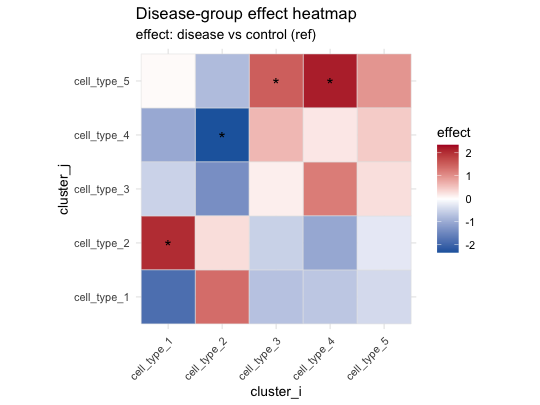

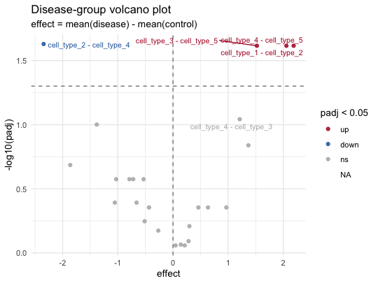

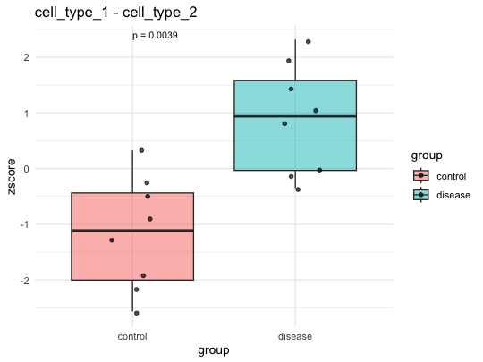

```r
plot_group_delta_heatmap(cmp_wilcox)
plot_volcano_groups(cmp_wilcox, label_top = 5)
plot_pair_boxplot(
  per_sample,
  value     = "zscore",
  pairs     = data.frame(cluster_i = "cell_type_1",
                         cluster_j = "cell_type_2"),
  add_p     = TRUE,
  ref_group = "control"
)
```

# Patient-level aggregation

If you have multiple images per patient and want one observation per patient, pass `unit = "patient"` to the `*_per_sample()` helpers. Each image-level result is then averaged within patient before group comparison:

```r
per_patient <- nhood_enrichment_per_sample(
  df_groups, sample_key = "sample_id", group_key = "group",
  cluster_key = "cell_type", patient_key = "patient",
  unit = "patient",
  neighbors.k = 15, n_perms = 100, n_jobs = 1
)
```

# Inputs other than a data.frame

All `*_per_sample()` helpers accept three kinds of input:

- A `Seurat` object with multiple images. `sample_key` is a column of `meta.data` whose values match `names(obj@images)`.
- A `list` of `Seurat` objects, where each may itself have multiple images. `source_index` in `build_sample_design()` records the list origin.
- A `data.frame` with `x`, `y`, the cluster column, and the sample / group / (optional) patient columns.

`build_sample_design()` is the small helper that turns any of these into the design table used downstream — call it directly if you only want the sample / group / patient mapping.

```r
build_sample_design(
  df_groups,
  sample_key  = "sample_id",
  group_key   = "group",
  patient_key = "patient"
)
```

```
#>           sample_id   group   patient source_index
#> disease_1 disease_1 disease disease_1            1
#> disease_2 disease_2 disease disease_2            1
#> disease_3 disease_3 disease disease_3            1
#> disease_4 disease_4 disease disease_4            1
#> disease_5 disease_5 disease disease_5            1
#> disease_6 disease_6 disease disease_6            1
#> disease_7 disease_7 disease disease_7            1
#> disease_8 disease_8 disease disease_8            1
#> control_1 control_1 control control_1            1
#> control_2 control_2 control control_2            1
#> control_3 control_3 control control_3            1
#> control_4 control_4 control control_4            1
#> control_5 control_5 control control_5            1
#> control_6 control_6 control control_6            1
#> control_7 control_7 control control_7            1
#> control_8 control_8 control control_8            1
```